# Final Report - Gapminder

Dayton

April 28, 2019

### Exploratory Data Analysis

I have decided to approach the gapminder data set provided for our research. The question I want to explore is:

**Is there a correlation between lifetime expectancy of a country and lifetime GDP of a country? If so, how strong is that correlation?**

I predict that if a country’s GDP grows over time then their life expectancy would as well due to GDP growth representing that a country is becoming more developed.

### Data Wrangling

```
## Observations: 41,284
## Variables: 6
## $ Country    <chr> "Afghanistan", "Afghanistan", "Afghanistan", "Afgha...
## $ Year       <int> 1800, 1801, 1802, 1803, 1804, 1805, 1806, 1807, 180...
## $ life       <dbl> 28.21100, 28.20075, 28.19051, 28.18026, 28.17001, 2...
## $ population <chr> "3280000", "", "", "", "", "", "", "", "", "", "328...
## $ income     <int> 603, 603, 603, 603, 603, 603, 603, 603, 603, 603, 6...
## $ region     <chr> "South Asia", "South Asia", "South Asia", "South As...
```

```
## [1] 41284     6
```

## Visual Analysis

### Exploratory

To start, I wanted to get a rough sketch of my relationship between income and life expectancy.

```r
gapminder3 %>% ggvis(~life, ~income, fill = ~region) %>% layer_points()
```

[output not shown]

### Cluster

My attempts at producing a cluster model through K-means and through Silhouette analysis were halted due *NA’s being introduced by coercion* for both methods. I have provided the code below as reference.

### K-means clustering

*gap_model <- kmeans(gapminder3, center = 6)*

*gapminder_cluster <- mutate(gapminder3, cluster = gap_model$cluster)*

*tot_withinss <- map_dbl(1:20, function(k){model <- kmeans(x = lineup, centers = k) model$tot.withinss})* *gap_elbow <- data.frame(k = 1:20, tot_withinss)*

*ggplot(gap_elbow, aes(x = k, y = tot_withinss)) +* *geom_line() +* *scale_x_continous (breaks = 20)*

### Silouette analysis

*gap_pam <- pam(gapminder3, k = 6)* *plot(silhouette(gap_pam))*

*gap_width <- map_dbl(2:20, function(k){gap_sil <- pam(x = gapminder3, k = k) gap_sil$silinfor$avg.width})*

*sil <- data.frame(k = 2:20, gap_width = gap_width)*

*ggplot(sil, aes(x = k, y = gap_width))+* *geom_line()+* *scale_x_continous(breaks = 2:20)*

I decided to go with 6 for my number of centroids on both analysis because I wanted to see if the data points would have clustered based on the number of regions I have in my data set, which is 6.

## Regression

### Gaussian Glm

In this regression I am looking at the affect income has on life, `life ~ income`. That is displayed in my `gap_gaus_glm` formula provided below:

```
    **gap_gaus_glm <- glm(life ~ income, data = gapminder3, family "gaussian")**
```

```r
summary(gap_gaus_glm)
```

```
##
## Call:
## glm(formula = life ~ income, family = "gaussian", data = gapminder3)
##
## Deviance Residuals:
##      Min        1Q    Median        3Q       Max
## -136.597    -8.726    -5.091    10.283    33.731
##
## Coefficients:
##              Estimate Std. Error t value Pr(>|t|)
## (Intercept) 3.873e+01  7.339e-02   527.7   <2e-16 ***
## income      9.217e-04  6.622e-06   139.2   <2e-16 ***
## ---
## Signif. codes:  0 '***' 0.001 '**' 0.01 '*' 0.05 '.' 0.1 ' ' 1
##
## (Dispersion parameter for gaussian family taken to be 174.069)
##
##     Null deviance: 10151093  on 38942  degrees of freedom
## Residual deviance:  6778419  on 38941  degrees of freedom
## AIC: 311444
##
## Number of Fisher Scoring iterations: 2
```

The equation above can be interpreted in standard form as such, life = 38.73 + .0009217*income. Now the interpretation is, for each dollar of income an individual makes their life expectancy is increased by .0009217 years. For an individual that brings in $15,000 a year would expect to live 52.5555.

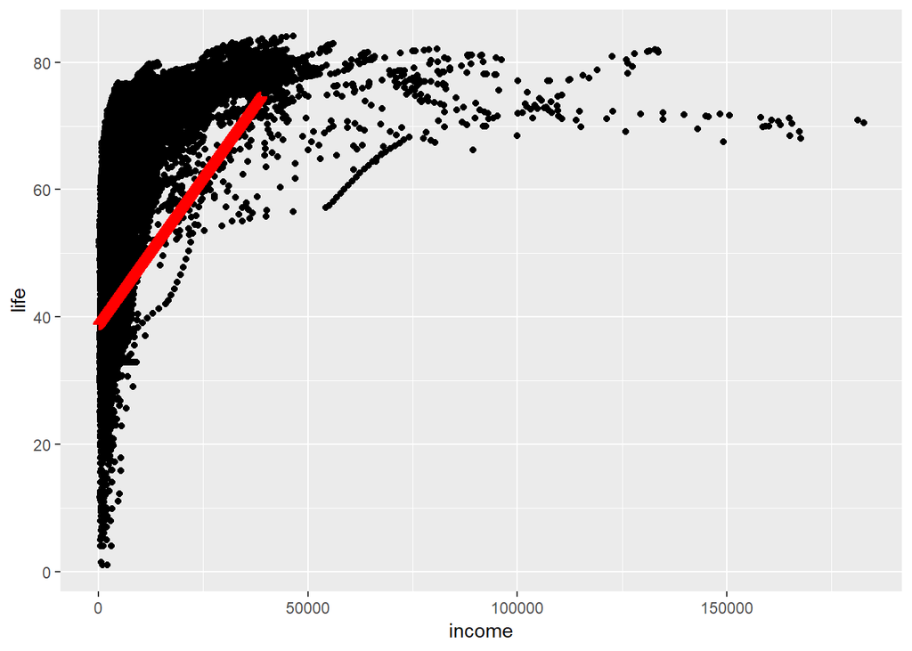

```r
ggplot(gapminder3)+
  geom_point(aes(x = income, y = life)) +
  geom_line(aes(x = income, y = predicted), color = 'red', size = 3, data = pred_gap)
```

As you can see by the graph provided above, the prediction, noted by the redline, shows a positive correlation between life and income. Before we could conclude our results, we must check for heterogeneity in our residuals to ensure there isn’t bias incorporated in our data set. If we do find bias then we will require a different type of model.

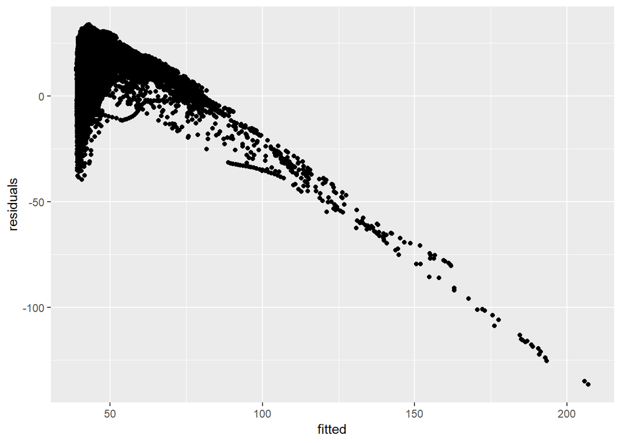

Unfortunately, as you can see by the graph above the residuals aren’t around the value of 0. The interpretation of this graph means there’s a lot of heterogeneity in our regression. The Gaussian model isn’t the correct model for this data set.

### Poisson Glm

```
          *gap_pois_glm <- glm(life~income, data = gapminder3, family = "poisson")*

                *gap_pois_income<- data.frame(income = seq(from = 1, to = 100))*

        *gap_pois_income$predicted <- predict(gap_pois_glm, gap_pois_income, type = "response")*

                                  *summary(gap_pois_glm)*
                                  *summary(gap_pois_income)*


                *ggplot(gapminder3)+
                    *geom_point(aes(x = income, y = life))+ *
                    *geom_line(aes(x = income, y = predicted, data = gap_pois_income))*


      *pois_diag <- data.frame(residuals = resid(gap_pois_glm), fitted = fitted(gap_pois_glm))*

                *dispersion(gap_pois_glm, modeltype = "poisson")*
```

### Poisson glm w/additional factors

With this regression model, there is a chance that of discovering another factor that could impact life expectancy for people. The new independent variable I choose to run the new analysis on was based on the region of the world a person came from. Now my new regression model would consist of life being my dependent variable and my two independet variables now would be income and region. Unforunately, without being able to run my Poisson Glm regression, I wasn’t able to reference the necessary variables to calculate my third regression. Once again I have provided the code chuncks below for reference.

```
        *gap_pois_factor <- glm(life ~income * region, data = gapminder3, family = "poisson")*

        *gap_pois_two <- expand.grind(income = seq(from 1, to = 100), region = c("America", "East Asia & Pacific", "Europe & Central Asia", "Middle East & North Africa", "South Asia", "Sub-Saharan Africa"))*

        *gap_pois_two$predicted <- predict(gap_pois_factor, gap_pois_two, type = "response")*

        *ggplot(gapminder3) +
          *geom_point(aes(x = income, y = life)) +*
          *geom_line(aes(x = income, y = predicted, col = region), data = gap_pois_two)*

        *pois2_diag <- data.frame(residuals = resid(gap_pois_factor), fitted = fitted(gap_pois_factor))*

        *ggplot(pois2_diag)+*
          *geom_point(aes(x = fitted, y = residuals))*

        *dispersion(gap_pois_factor, modeltype = "poisson")*
```

# Analysis

The question I asked at the start of my analysis was, what impact did `income` have on life expectancy? From the results I was able to gather, `income` had a positive impact on life expectancy. The amount of impact though couldn’t be fully trusted because my results from the Gaussian Model showed my model incoporated bias. If this research could be done again, I would incorporate the region variable within my analysis. I believe this variable would reduce the amount of bias in the model, but not to to zero.